# Analysis of `california_housing` dataset

Matteo Lisi

2025-02-14

## Dataset

Load the training data into R

```r
d_train <- read.csv("california_housing_train.csv")
str(d_train)
```

```
## 'data.frame':    100 obs. of  15 variables:
##  $ lon    : num  -71.1 -71.1 -71 -71.1 -71.1 ...
##  $ lat    : num  42.2 42.2 42.2 42.2 42.2 ...
##  $ medv   : num  22.5 46.7 11.3 25 33.2 36 17.5 22.5 21.8 36.1 ...
##  $ crim   : num  0.252 0.298 9.187 0.198 0.105 ...
##  $ zn     : num  0 0 0 0 40 20 0 0 0 33 ...
##  $ indus  : num  10.59 6.2 18.1 10.59 6.41 ...
##  $ chas   : int  0 0 0 0 1 0 0 0 0 0 ...
##  $ nox    : num  0.489 0.504 0.7 0.489 0.447 0.647 0.442 0.449 0.532 0.472 ...
##  $ rm     : num  5.78 7.69 5.54 6.18 7.27 ...
##  $ age    : num  72.7 17 100 42.4 49 100 48.5 45.1 40.3 41.1 ...
##  $ dis    : num  4.35 3.38 1.58 3.95 4.79 ...
##  $ rad    : int  4 8 24 4 4 5 3 3 24 7 ...
##  $ tax    : int  277 307 666 277 254 264 352 247 666 222 ...
##  $ ptratio: num  18.6 17.4 20.2 18.6 17.6 13 18.8 18.5 20.2 18.4 ...
##  $ lstat  : num  18.06 3.92 23.6 9.47 6.05 ...
```

## Model specification

Rather than committing to a single model here I want to consider all possible models, that is including all possible subsets and combinations of the variables. I can do this automatically in R as follow:

```r
var_list <- colnames(d_train[,-which(colnames(d_train)=="medv")])
dependent_var <- "medv"

# empty list to hold all formulae
all_formulas <- list()

# generate combinations of variables
for(i in 1:length(var_list)){
  combinations <- combn(var_list, i)
  num_combinations <- ncol(combinations)

  # loop over combinations and create formulas
  for(j in 1:num_combinations){
    formula <- paste(dependent_var, "~",
                     paste(combinations[,j], collapse="+"))

    all_formulas <- c(all_formulas, formula)
  }
}
```

This creates 16383 possible models

```r
length(all_formulas)
```

```
## [1] 16383
```

As an example, here are 5 randomly selected formulas out of all possible ones:

```r
all_formulas[sample(length(all_formulas), 5)]
```

```
## [[1]]
## [1] "medv ~ lon+age+rad+tax"
##
## [[2]]
## [1] "medv ~ lon+crim+zn+nox+age+dis+rad+tax+ptratio"
##
## [[3]]
## [1] "medv ~ lon+lat+zn+indus+nox+rm+age+tax+ptratio"
##
## [[4]]
## [1] "medv ~ crim+chas+nox+dis+rad+tax+lstat"
##
## [[5]]
## [1] "medv ~ lon+lat+zn+nox+rm+dis+rad"
```

## Model evaluation and selection via cross-validation

### Custom function for LOO cross-validation

First I prepare a custom function that takes the dataset and a formula as input, run a leave-one-out cross-validation. The function return the cross-validated estimates of the mean squared error and the $R^2$, that is the proportion of variance explained.

```r
loocrossval <- function(mydata, formula){
  n <- nrow(mydata)  # Total number of observations
  preds <- numeric(n)  # Placeholder for predictions

  # Extract the outcome name from the formula
  outcome_var <- all.vars(as.formula(formula))[1]

  # Leave-One-Out Cross-Validation
  for (i in 1:n) {

    # Define training and test sets
    train_data <- mydata[-i, ]  # All except the i-th observation
    test_data  <- mydata[i,  ]  # The i-th observation

    # Fit the model
    model <- lm(formula, data = train_data)

    # Predict for the left-out observation
    preds[i] <- predict(model, newdata = test_data)
  }

  # Compute Mean Squared Error
  mse_loo <- mean((mydata[[outcome_var]] - preds)^2)
  rsquared_loo <- 1 - (mse_loo/mean((mydata[[outcome_var]] - mean(mydata[[outcome_var]]))^2))

  # return results as named vector
  res <- c(mse_loo, rsquared_loo)
  names(res) <- c("MSE","r-squared")

  # result
  return(res)
}
```

### Test all models

Now I can fit all the 16383 possible models using a loop, and estimate their out-of-sample predictive performance using LOO cross-validation (the formula that we have defined above).

**Warning: this may take a long time to complete!**

```r
m <- list() # an empty list
results <- data.frame()

# warning: this step may take some time to complete!
for (i in 1:length(all_formulas)) {
  m[[i]] <- lm(all_formulas[[i]], data = d_train)

  crossval_res <- loocrossval(d_train, all_formulas[[i]])

  # print some output to show progress
  cat("model ",i, "out of ", length(all_formulas), "completed:\n")
  print(crossval_res)
  cat("\n\n")

  results <- rbind(results,
                   data.frame(MSE= crossval_res["MSE"],
                            r_squared = crossval_res["r-squared"],
                            formula = all_formulas[[i]]))
}
```

The results will look like this (using the `head()` function to display the first few rows)

```r
head(results)
```

```
##           MSE    r_squared      formula
## MSE  87.76874 -0.001004347   medv ~ lon
## MSE1 90.06561 -0.027200198   medv ~ lat
## MSE2 79.97468  0.087887053  medv ~ crim
## MSE3 81.65028  0.068776832    medv ~ zn
## MSE4 62.46558  0.287578712 medv ~ indus
## MSE5 90.96837 -0.037496226  medv ~ chas
```

### Find best model

The best model is the one that achieve the smallest MSE error in the LOO cross-validation. WE can find it by indexing the MSE column in the results

```r
best_formula <- results$formula[results$MSE==min(results$MSE)]
print(best_formula)
```

[output not shown]

In terms of performance, the best model has the following cross-validated MSE error and r-squared:

```r
# LOO MSE error of best model
results$MSE[results$MSE==min(results$MSE)]
```

```
## [1] 13.27313
```

```r
# LOO r-squared of best model
results$r_squared[results$MSE==min(results$MSE)]
```

```
## [1] 0.8486196
```

The cross-validation tells us that this model is likely to generalise well to new, unseen data.

**However because we have used the cross-validation to select the model feature we should not take the MSE and r-squared at face value, as they are likely to overestimate the true predictive performance of the model. Since the same data was used for both feature selection and evaluation, these performance metrics do not provide a truly unbiased estimate of the model’s ability to generalize to new data.**

**In the study on suicidal ideation (see Moodle) the authors made a similar mistake, and claimed to have over 90% accuracy in discriminating suicidal ideators from control. This estimate was inflated, which led to the retraction of the study.**

## Out-of-sample test

When we test our best model in the real test set, we see that the performance is less impressive. Firstly, load the test set

```r
# load test set
d_test <- read.csv("california_housing_test.csv")
```

Next, let’s estimate the parameters of the best model — *importantly this need to be done using the training data!*

```r
# estimate the model parameters using training set data
best_model <- lm(best_formula, data = d_train)
```

Compute the predicted values:

```r
# Predict values of test data
preds <- predict(best_model, newdata = d_test)
```

Calculate performance in test set:

```r
test_mse <- mean((d_test$medv - preds)^2)
test_rsquared <- 1 - (test_mse/mean((d_test$medv- mean(d_test$medv))^2))
```

We can see that the MSE is larger (the MSE cross-validated in the training set was 13.27), indicating larger errors:

```r
test_mse
```

```
## [1] 38.94542
```

And the r-squared (proportion of variance explained) is lower (the r-squared cross-validated in the training set was 0.85)

```r
test_rsquared
```

```
## [1] 0.5304341
```

## Take-home

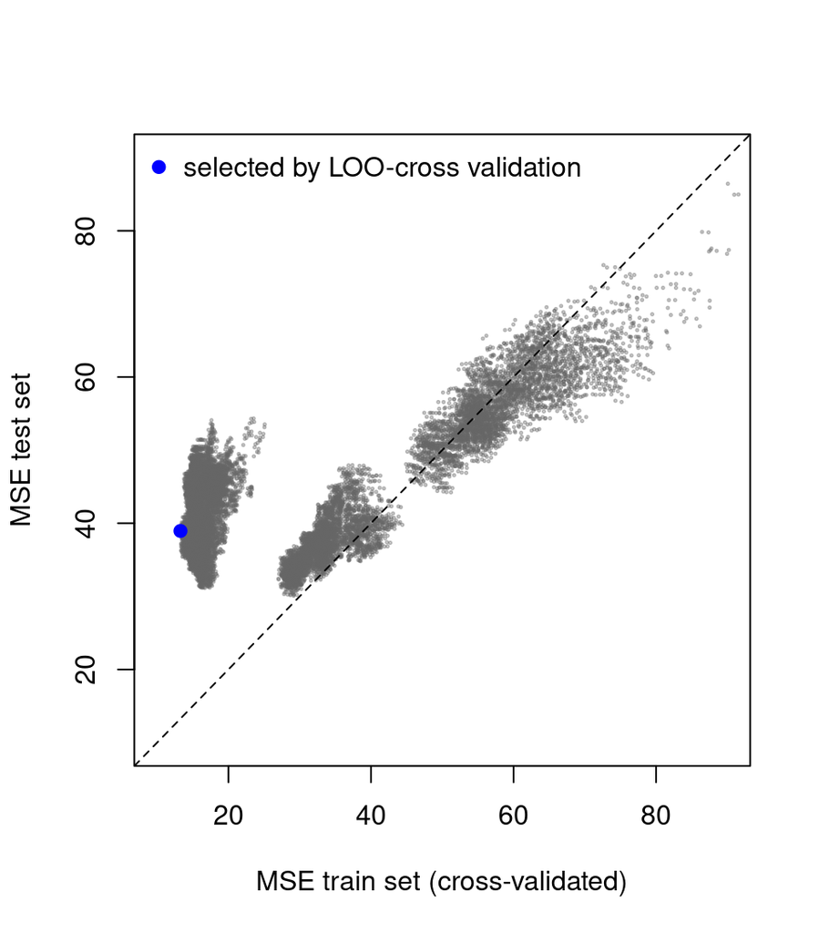

Each grey dot is a distinct model (16383 in total), characterised by a different combinations of predictors. On the horizontla axis is the cross-validated mean squared error (MSE) in the training data, whereas on the vertical axis is the MSE on the test data. The blue dot indicates the best model according to the LOO cross-validation procedure run on the training data.